# Housing Price vs. Supply 2024

Stephanie Armstrong, Ilgaz Kuscu, Alexander D. Silberman, Baylee Wechsler

2025-10-17

```r
rm(list=ls())
```

```r
library(ezids)
library(ggplot2)
library(dplyr)
library(readr)
library(tidyverse)
library (tidyr)
library(janitor)
library(scales)
library(ggrepel)
library(corrplot)
library(tigris)
library(sf)
library(ggridges)
library(scales)
library(tidytext)
```

## Introduction

Supply and demand is a classic and well-known economic model. However, real life is far more nuanced than the simple version of this model that many are familiar with. We wanted to use real housing price and supply samples to explore how well that relationship fits economic theory. Our research question is: How is the supply of housing related to average home prices across U.S. metropolitan areas in the year 2024?

In 2024, the housing market had more sellers than buyers. Normally, the excess supply in a buyer’s market would place downward pressure on prices, but concurrent economic monetary situation stalled that natural phenomenon. These unusual market conditions make it important to examine their wider economic and social impacts.

Accordingly, the relevance of our question extends beyond economics, since housing prices directly affect households, companies, and wealth inequality. Rising home prices lead to wage increases, which in turn raise the cost of goods and services—creating a vicious cycle that fuels inflation. As uncontrolled inflation deteriorates living standards, companies struggle to attract and retain workers due to reduced labor mobility. Consequently, some firms relocate to more affordable states to balance operational costs.

At the same time, while rising housing costs create financial burdens for renters, homeowners benefit from accumulating wealth through year-over-year appreciation and rental income. In fact, the wealth gap between homeowners and renters has reached a historic high, as housing costs have grown faster than incomes (Urban Institute, 2023).

Throughout our analysis, we cross-checked our findings with existing research and market reports to better understand these dynamics. In 2024, there were nearly 500000 more sellers than buyers (Redfin, 2025). Despite this apparent “buyer’s market,” prices did not decline as economic theory might predict. One possible explanation is that the elasticity of housing supply—the degree to which new construction responds to price changes—has been steadily declining since the Great Recession (CEPR / VoxEU, 2024).

Additionally, median home prices have more than doubled over the past decade, rising faster than both wages and inflation (Chamber of Commerce, 2024). This growing affordability crisis hinders job creation, encourages corporate relocations, and causes states to lose billions of dollars in economic output (Pebble Cap., 2024).

## Data

This project uses the State and County Housing Market Indicators dataset from the American Enterprise Institute Housing Center (American Enterprise Intsitute Housing Center, 2024). The variables are:

| Original Variable Name | New Variable Name | Definition |
| --- | --- | --- |
| State | State | state |
| County | County_Name | County |
| FIPS | FIPS_County_Code | 5-digit Federal Information Processing Series codes (first 2 digits indicate state, last 3 indicate sub-county entity) |
| Year | Year | Year when the data was collected |
| Tier | Affordability | Categorizes home sales into entry-level (<=80th percentile of FHA sales prices), move-up (all others), and all |
| Median.Sale.Price..in.Thousands. | Median_Sale_Price_in_k | Median sale price in thousands of USD per county |
| House.Price.Appreciation.since.2012 | House_Price_Appreciation_since_2012_percent | Cumulative home price appreciation since 2012 |
| House.Price.Appreciation..Year.over.Year | House_Price_Appreciation_yr_over_yr_percent | Home price appreciation since the previous year |
| Months..Supply | Months_Supply | Number of months it would take for the inventory of existing homes for sale to be exhausted at the current sales pace |
| New.Construction.Share.of.Sales | New_Constr_by_share_of_sales_percent | Percent of sales comprising new construction |
| Mortgage.Default.Rate | Mortgage_Default_Rate_percent | AEI Mortgage Default Rate, a measure of how loans originating in a given month would perform under the same conditions as the 2007 financial crisis (<=7%: Low Risk; between 7.01% and 14%: Medium Risk;… |

### Data Sources

The AEI Housing Center itself primarily gathered data from public records from First American via Data Tree; specifically, it retrieved data from deed and tax assessor files about where homes were located, their prices, and when the deal took place.

In addition, data for calculating AEI’s Mortgage Default Rate were pulled from numerous sources: - Home Mortgage Disclosure Act (HMDA) - National Mortgage Default Rate - CoreLogic’s Loan Level Market Analytics (LLMA) - ICE’s McDash - Fannie Mae Single-Family Loan Performance - Freddie Mac Single Family Loan Level Data - Federal Housing Association Snapshot

Approximately 60–65% of public records were able to be cross-referenced in this way, though the exact number depends on the locale. These were then weighted up to account for the incomplete data; according to AEI, this is representative of overall public records data

Lastly, data for calculating Months’ Supply was taken from Zillow and Realtor.com, and calculated as $\frac{\text{Listings Counts}}{\text{Existing Home Sales.}}$

### Limitations

The weakness of Months’ Supply as a proxy for supply should here be noted. Months’ Supply may be low for one of two reasons: supply and demand are both high, or supply and demand are both low. As such, it is not ideal for discovering how supply alone affects median sale price. The exact counts, adjusted for population, would be far more useful,

### Load and Clean Data

```r
housing = read.csv("..\\Data\\state_county_data_download_2025.csv")
#dplyr::slice_sample(housing, n = 5) %>% xkabledply()
```

The data is limited to the year 2024, and the variables are renamed for clarity. Additionally, data related to the armed forces are excluded, as that is outside the scope of the research question.

```r
housing_2024 = housing %>% filter(housing$Year == 2024,
                                  housing$State != 'AA National',
                                  housing$County != 'AA State') %>% #excluding the armed forces

#rename cols
rename(
  Median_Sale_Price_in_k = Median.Sale.Price..in.Thousands.,
  House_Price_Appreciation_yr_over_yr_percent = House.Price.Appreciation..Year.over.Year.,
  House_Price_Appreciation_since_2012_percent = House.Price.Appreciation.since.2012,
  Months_Supply = Months..Supply,
  New_Constr_by_share_of_sales_percent = New.Construction.Share.of.Sales,
  Mortgage_Default_Rate_percent = Mortgage.Default.Rate,
  County_Name = County,
  FIPS_County_Code = FIPS,
  Affordability = Tier
)
xkabledplyhead(housing_2024)
```

Head

| State | County_Name | FIPS_County_Code | Year | Affordability | Median_Sale_Price_in_k | House_Price_Appreciation_since_2012_percent | House_Price_Appreciation_yr_over_yr_percent | Months_Supply | New_Constr_by_share_of_sales_percent | Mortgage_Default_Rate_percent |
| --- | --- | --- | --- | --- | --- | --- | --- | --- | --- | --- |
| AK | Aleutians East Borough | 2013 | 2024 | all | NA |  |  | NA |  |  |
| AK | Aleutians East Borough | 2013 | 2024 | entrylevel | NA |  |  | NA |  |  |
| AK | Aleutians East Borough | 2013 | 2024 | moveup | NA |  |  | NA |  |  |
| AK | Aleutians West Census Area | 2016 | 2024 | all | NA |  |  | 1.8 |  |  |
| AK | Aleutians West Census Area | 2016 | 2024 | entrylevel | NA |  |  | 2.8 |  |  |

The typing of the variables is corrected. Some require further processing by removal of the symbols “$”, “,”, and “%” before they may be cast. Once this is performed, NAs are omitted from *Median_Sale_Price_in_k*; other dependent variables (House Price Appreciation, Mortgage Default Rate) also contained NAs, but, as these were less central to our research question and because we wanted to use as much data as possible, we declined to remove these.

```r
# as factors
housing_2024$State = as.factor(housing_2024$State)
housing_2024$County_Name = as.factor(housing_2024$County_Name)
housing_2024$FIPS_County_Code = as.factor(housing_2024$FIPS_County_Code)
housing_2024$Affordability = as.factor(housing_2024$Affordability)

# remove prefixes '$' and '%' from values
housing_2024 = housing_2024 %>%
  mutate(Median_Sale_Price_in_k = gsub("[\\$,]", "", Median_Sale_Price_in_k),
         House_Price_Appreciation_since_2012_percent =
           gsub("[%,]","",House_Price_Appreciation_since_2012_percent),
         House_Price_Appreciation_yr_over_yr_percent =
           gsub("[%,]","",House_Price_Appreciation_yr_over_yr_percent),
         New_Constr_by_share_of_sales_percent = gsub("[%,]","",New_Constr_by_share_of_sales_percent),
         Mortgage_Default_Rate_percent = gsub("[%,]","",Mortgage_Default_Rate_percent))
###I included the commas to be removed as well indicated in the brackets. SA

#as num instead of chr
housing_2024$Median_Sale_Price_in_k = as.numeric(housing_2024$Median_Sale_Price_in_k)
housing_2024$House_Price_Appreciation_since_2012_percent =
  as.numeric(housing_2024$House_Price_Appreciation_since_2012_percent)
housing_2024$House_Price_Appreciation_yr_over_yr_percent =
  as.numeric(housing_2024$House_Price_Appreciation_yr_over_yr_percent)
housing_2024$New_Constr_by_share_of_sales_percent =
  as.numeric(housing_2024$New_Constr_by_share_of_sales_percent)
housing_2024$Mortgage_Default_Rate_percent = as.numeric(housing_2024$Mortgage_Default_Rate_percent)
###I included the commas to be removed as well indicated in the brackets. SA

#moving the na dropping to after the parsing
housing_2024 <- housing_2024 %>%
  tidyr::drop_na(Median_Sale_Price_in_k)

#view data
housing_2024 %>% slice_sample(n=5) %>% xkabledply()
```

Table

| State | County_Name | FIPS_County_Code | Year | Affordability | Median_Sale_Price_in_k | House_Price_Appreciation_since_2012_percent | House_Price_Appreciation_yr_over_yr_percent | Months_Supply | New_Constr_by_share_of_sales_percent | Mortgage_Default_Rate_percent |
| --- | --- | --- | --- | --- | --- | --- | --- | --- | --- | --- |
| MI | Houghton County | 26061 | 2024 | moveup | 335 | 95.1 | 4.4 | 5.8 | 5.8 | 4.9 |
| KY | Kenton County | 21117 | 2024 | entrylevel | 213 | 114.0 | 8.8 | 1.8 | 8.4 | 15.4 |
| CO | Montezuma County | 8083 | 2024 | entrylevel | 280 | 127.3 | 7.5 | 3.3 | 5.6 | 10.4 |
| IN | Fayette County | 18041 | 2024 | moveup | 307 | 105.5 | 12.6 | 5.1 | 0.0 | NA |
| ND | Eddy County | 38027 | 2024 | moveup | 600 | NA | NA | 24.0 | 100.0 | NA |

After cleaning, there are 8184 observations remaining.

However, the presence of the variable *Affordability* means there are three observations associated with each FIPS code: one for Entry-Level homes, one for Move-Up homes, and one that is a combination of the two (“all”). As, for the majority of our purposes, we only want one data point per FIPS code, the dataframe is split in two: one containing the tiered data (*housing_2024_tiers*), and the second containing only the combined data (*housing_2024_all*).

```r
housing_2024_all = housing_2024 %>% filter(housing_2024$Affordability == "all")

#creating df w/ affordability all totals and then another with entry level/moving up totals
housing_2024_tiers <- housing_2024 %>%
  dplyr::filter(Affordability %in% c("entrylevel","moveup")) %>%
  dplyr::mutate(
    Affordability = factor(Affordability,
                           levels = c("entrylevel","moveup"),
                           labels = c("Entry-Level","Move-Up"))
  )
```

## Exploratory Data Analysis (EDA)

### Summary Statistics

Looking across all U.S. counties in our data set, the typical home price sat at around $200K, though the mean is pulled up by a handful of very expensive markets. Average months of supply was about 3, and well below the 5-6 months that indicate a balanced market. Demand is still outpacing what’s available.

Despite the tight market, prices rose around 6% year-over-year, and new construction only made up about 6-10% of total sales. Even from the top level data, we can already suspect the pattern: lower supply corresponds with stronger price growth.

```r
#summary stats on new df's
xkablesummary(housing_2024_all)
```

Table: Statistics summary.

|  | State | County_Name | FIPS_County_Code | Year | Affordability | Median_Sale_Price_in_k | House_Price_Appreciation_since_2012_percent | House_Price_Appreciation_yr_over_yr_percent | Months_Supply | New_Constr_by_share_of_sales_percent | Mortgage_Default_Rate_percent |
| --- | --- | --- | --- | --- | --- | --- | --- | --- | --- | --- | --- |
| Min | TX : 217 | Washington County: 27 | 1001 : 1 | Min. :2024 | all :2754 | Min. : 17 | Min. : 3.7 | Min. :-28.70 | Min. : 0.10 | Min. : 0.0 | Min. : 0.5 |
| Q1 | GA : 159 | Jefferson County : 24 | 1003 : 1 | 1st Qu.:2024 | entrylevel: 0 | 1st Qu.: 140 | 1st Qu.: 88.9 | 1st Qu.: 3.00 | 1st Qu.: 2.20 | 1st Qu.: 2.9 | 1st Qu.:11.4 |
| Median | KY : 114 | Franklin County : 21 | 1005 : 1 | Median :2024 | moveup : 0 | Median : 200 | Median :107.3 | Median : 5.95 | Median : 3.00 | Median : 6.4 | Median :14.5 |
| Mean | VA : 108 | Lincoln County : 20 | 1007 : 1 | Mean :2024 | NA | Mean : 242 | Mean :113.3 | Mean : 6.00 | Mean : 3.44 | Mean : 9.5 | Mean :14.8 |
| Q3 | NC : 100 | Jackson County : 19 | 1009 : 1 | 3rd Qu.:2024 | NA | 3rd Qu.: 303 | 3rd Qu.:132.6 | 3rd Qu.: 8.60 | 3rd Qu.: 4.10 | 3rd Qu.:12.5 | 3rd Qu.:17.6 |
| Max | IA : 99 | Madison County : 19 | 1017 : 1 | Max. :2024 | NA | Max. :2300 | Max. :278.0 | Max. : 89.20 | Max. :24.00 | Max. :75.4 | Max. :36.0 |
| NA | (Other):1957 | (Other) :2624 | (Other):2748 | NA | NA | NA | NA’s :294 | NA’s :302 | NA’s :3 | NA | NA’s :324 |

To understand whether that same relationship holds across different parts of the market, we split the data into separate affordability tiers: entry-level and move-up homes, and compared how price and supply interact within each group.

Entry-level homes were far cheaper, with a typical price around $155K, but the tightest market at about only 2 months of supply. That scarcity was pushing prices up about 6% year-over-year, while new construction made up only about 4% of sales. Builders weren’t adding enough stock to relieve the pressure.

Move-up homes had a median price of more than $400K, doubling the entry-level tier. In contrast, they show a more balanced 5-6 months of supply, slower appreciation at roughly 5%, and far more new construction at about 13%.

Together, these tiers reveal a consistent pattern: markets with tighter supply experience faster price growth, while greater inventory and new construction at the higher end help moderate prices.

```r
#comparing tiers entrylevel and moveup
#entrylevel
xkablesummary(df = subset(housing_2024_tiers,
                          Affordability == "Entry-Level"),
              title = "Summary Statistics: Entry-Level Homes",
              digits = 2,
              pos = "left",
              bso = "striped")
```

Summary Statistics: Entry-Level Homes

|  | State | County_Name | FIPS_County_Code | Year | Affordability | Median_Sale_Price_in_k | House_Price_Appreciation_since_2012_percent | House_Price_Appreciation_yr_over_yr_percent | Months_Supply | New_Constr_by_share_of_sales_percent | Mortgage_Default_Rate_percent |
| --- | --- | --- | --- | --- | --- | --- | --- | --- | --- | --- | --- |
| Min | TX : 212 | Washington County: 27 | 1001 : 1 | Min. :2024 | Entry-Level:2747 | Min. : 14 | Min. : 4.5 | Min. :-28.90 | Min. : 0.00 | Min. : 0.0 | Min. : 0.8 |
| Q1 | GA : 159 | Jefferson County : 24 | 1003 : 1 | 1st Qu.:2024 | Move-Up : 0 | 1st Qu.:111 | 1st Qu.: 88.9 | 1st Qu.: 3.00 | 1st Qu.: 1.70 | 1st Qu.: 1.7 | 1st Qu.:13.6 |
| Median | KY : 114 | Franklin County : 21 | 1005 : 1 | Median :2024 | NA | Median :155 | Median :107.3 | Median : 6.20 | Median : 2.20 | Median : 4.2 | Median :16.3 |
| Mean | VA : 108 | Lincoln County : 20 | 1007 : 1 | Mean :2024 | NA | Mean :181 | Mean :113.7 | Mean : 6.31 | Mean : 2.51 | Mean : 7.1 | Mean :16.5 |
| Q3 | NC : 100 | Jackson County : 19 | 1009 : 1 | 3rd Qu.:2024 | NA | 3rd Qu.:230 | 3rd Qu.:133.3 | 3rd Qu.: 9.40 | 3rd Qu.: 3.00 | 3rd Qu.: 9.2 | 3rd Qu.:19.3 |
| Max | IA : 99 | Madison County : 19 | 1017 : 1 | Max. :2024 | NA | Max. :750 | Max. :279.1 | Max. : 86.80 | Max. :24.00 | Max. :76.2 | Max. :36.0 |
| NA | (Other):1955 | (Other) :2617 | (Other):2741 | NA | NA | NA | NA’s :293 | NA’s :300 | NA’s :6 | NA | NA’s :333 |

```r
#moveup
xkablesummary(df = subset(housing_2024_tiers,
                          Affordability == "Move-Up"),
              title = "Summary Statistics: Move-Up Homes",
              digits = 2,
              pos = "left",
              bso = "striped")
```

Summary Statistics: Move-Up Homes

|  | State | County_Name | FIPS_County_Code | Year | Affordability | Median_Sale_Price_in_k | House_Price_Appreciation_since_2012_percent | House_Price_Appreciation_yr_over_yr_percent | Months_Supply | New_Constr_by_share_of_sales_percent | Mortgage_Default_Rate_percent |
| --- | --- | --- | --- | --- | --- | --- | --- | --- | --- | --- | --- |
| Min | TX : 193 | Washington County: 26 | 1001 : 1 | Min. :2024 | Entry-Level: 0 | Min. : 200 | Min. : 24.9 | Min. :-32.90 | Min. : 0.20 | Min. : 0.0 | Min. : 0.2 |
| Q1 | GA : 159 | Jefferson County : 24 | 1003 : 1 | 1st Qu.:2024 | Move-Up :2683 | 1st Qu.: 350 | 1st Qu.: 81.8 | 1st Qu.: 2.40 | 1st Qu.: 3.70 | 1st Qu.: 5.6 | 1st Qu.: 7.8 |
| Median | KY : 112 | Franklin County : 21 | 1005 : 1 | Median :2024 | NA | Median : 414 | Median :100.2 | Median : 4.90 | Median : 5.50 | Median : 12.6 | Median :10.2 |
| Mean | VA : 106 | Lincoln County : 20 | 1007 : 1 | Mean :2024 | NA | Mean : 463 | Mean :103.6 | Mean : 5.22 | Mean : 6.44 | Mean : 15.6 | Mean :11.3 |
| Q3 | NC : 100 | Jackson County : 19 | 1009 : 1 | 3rd Qu.:2024 | NA | 3rd Qu.: 510 | 3rd Qu.:122.2 | 3rd Qu.: 7.60 | 3rd Qu.: 7.90 | 3rd Qu.: 22.2 | 3rd Qu.:13.5 |
| Max | IA : 99 | Madison County : 19 | 1017 : 1 | Max. :2024 | NA | Max. :4400 | Max. :240.1 | Max. : 55.90 | Max. :24.00 | Max. :100.0 | Max. :36.0 |
| NA | (Other):1914 | (Other) :2554 | (Other):2677 | NA | NA | NA | NA’s :682 | NA’s :695 | NA’s :14 | NA | NA’s :393 |

### Correlation Heatmap of Numeric Variables

Before we began analyzing specific variables, we constructed a heatmap to see the general magnitude and direction of correlational relationships among our variables.

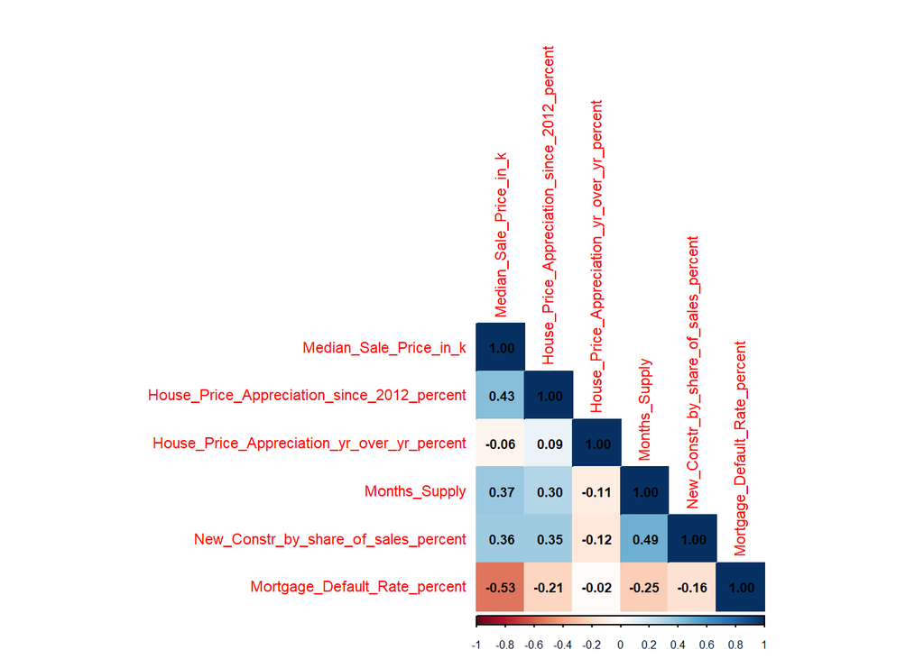

```r
#correlation heatmap of numeric variables w/ ..._all df
housing_numeric_all <- housing_2024_all %>%
  select(where(is.numeric) & !all_of("Year")) %>%
  drop_na()

cor_matrix_all <- cor(housing_numeric_all)

corrplot(cor_matrix_all, method = "color",
         type = "lower",
         tl.cex = 0.7,
         addCoef.col = "black",
         number.cex=0.6,
         cl.cex = 0.5,
         bg = "transparent")
```

```r
# saves plot
# png(file = "housing_corr_plot.png", type="windows", bg = "transparent")
#
# corrplot(cor_matrix_all, method = "color",
#          type = "lower",
#          # tl.cex = 0.7,
#          addCoef.col = "black",
#          # number.cex=0.6,
#          #cl.cex = 0.5,
#          bg = "transparent")
#
# dev.off()
#interesting to see positive and inverse relationships between variables
#did not scan for no relationships
```

A few notes immediately stand out: some expected, others less so.

House Price Appreciation year over year does not correlate linearly with House Price Appreciation since 2012; it seems like, at least for 2024, it is independent of what came before. Of the two, only one correlates with Median Sale Price: Appreciation since 2012, as expected—the higher the overall appreciation, the higher the price.

New construction correlates with Months’ Supply: the more housing is being built, the longer it’ll take to sell all those houses.

Mortgage Default Rate correlates negatively with Median Sale Price: the lower the sales price, the higher the risk of defaulting on your mortgage—those who can’t afford mortgages purchase less expensive houses.

Surprisingly, Months’ Supply correlates positively with Median Sale Price, not negatively. There is a logical explanation, but only if causality is reversed from our expectations: the higher the price, the longer a home will take to sell. This does, unfortunately, emphasize the flaws in using this dataset to answer our question.

### Price Distributions by Tier

When we compare the price distributions between the tiers, move-up homes clearly sat at the higher level, with a median price about double those of entry-level. With the move-up tier showing more extreme outliers and a much wider range, we can see greater price volatility and a concentration of higher-value counties, confirming that affordability tiers meaningfully segmenting the housing market.

Entry-level homes cluster tightly at the lower end, showing limited price variation and reinforcing how constrained the affordability housing stock really is. Together these differences help answer our core question: when supply is tight at the lower end, prices rise fastest there.

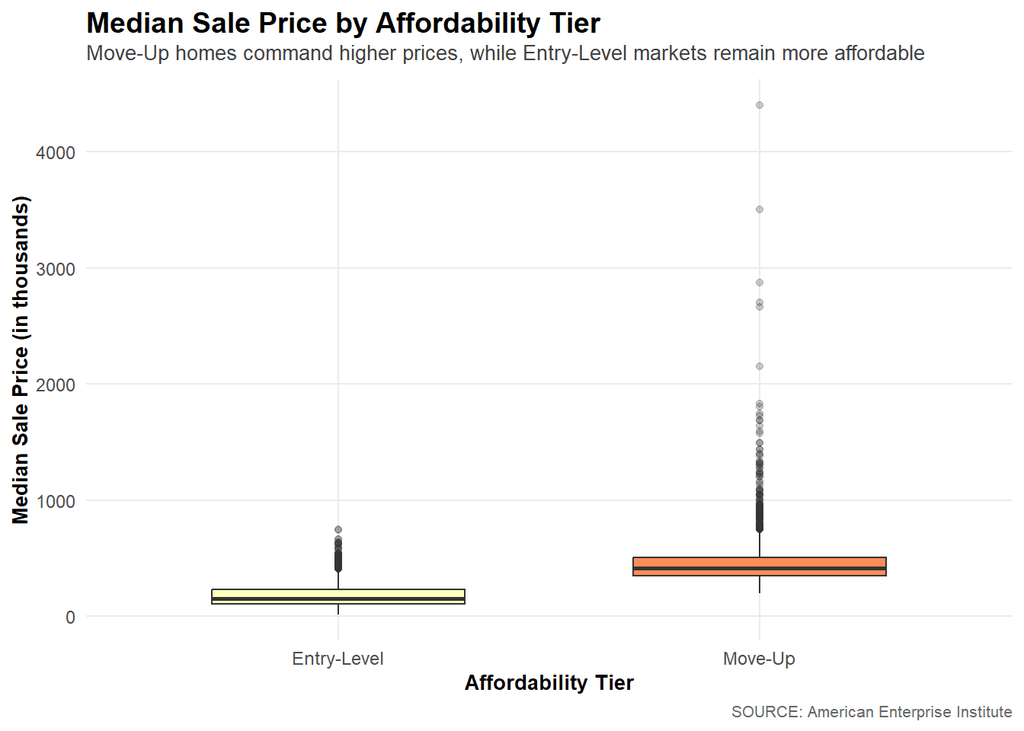

```r
#box plotting by affordability tiers from tiers df
housing_afford_box <- ggplot(housing_2024_tiers,
                             aes(x = Affordability,
                                 y = Median_Sale_Price_in_k,
                                 fill = Affordability)) +
  geom_boxplot(width = 0.6,
               outlier.alpha = 0.25) +
  scale_fill_brewer(palette = "RdYlBu", direction = -1, guide = "none") +
  labs(
    title = "Median Sale Price by Affordability Tier",
     subtitle = "Move-Up homes command higher prices, while Entry-Level markets remain more affordable",
    x = "Affordability Tier",
    y = "Median Sale Price (in thousands)",
    caption = "SOURCE: American Enterprise Institute") +
  theme_minimal(base_size = 11) +
  theme(plot.title = element_text(face = "bold",
                                  size = 14,
                                  margin = margin(b = 3)),
        plot.subtitle = element_text(size = 10,
                                     color = "gray25",
                                     margin = margin(b = 8)),
        axis.title = element_text(size = 10,
                                  face = "bold"),
        axis.text = element_text(size = 9),
        plot.caption = element_text(size = 8,
                                    color = "gray40",
                                    hjust = 1),
        panel.grid.minor = element_blank(),
        panel.background = element_blank(),
        plot.background  = element_blank())

housing_afford_box
```

```r
#ggsaving
#ggsave(plot = housing_afford_box,
       # filename = "housing_afford_box.png",
       # width = 7,
       # height = 4,
       # dpi = 500,
       # bg = "transparent")
```

### Geographic Price Patterns

Looking at the nation as a whole, we see how home prices vary sharply across regions, revealing a clear geographic divide by affordability. The blues dominate the Midwest and the South, reflecting lower typical prices and more accessible markets, while reds cluster along major metropolitan areas and the coasts, where housing was far more expensive.

This spatial pattern highlights a regional trend: interior counties remain relatively affordable while coastal regions continue to experience elevated prices. These high-priced areas also tend to align with regions known for limited housing supply and high demand, suggesting that geographic supply constraints are a major factor driving price growth in these markets.

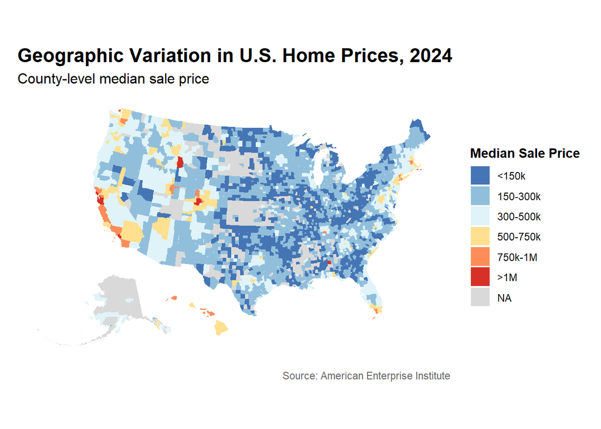

```r
##basemap

#reading in counties spatial file from tigris package
counties_2024 <- counties(year = 2013,
                          cb = TRUE,
                          class = "sf",
                          progress_bar = FALSE)

#excluding territories and shifting AK/HI
counties_2024 <- counties_2024 %>%
  filter(as.numeric(STATEFP) < 60) %>%
  shift_geometry()

#removing duplicate columns
counties_2024 <- counties_2024 %>%
  select(-NAME)

#creating basemap and checking
counties_2024_basemap <- ggplot() +
  geom_sf(data = counties_2024) +
  theme_void()

#counties_2024_basemap

##prepping and merging housing_2024_all w/ counties_2024

housing_2024_all <- housing_2024_all %>%
  mutate(price_bin = cut(Median_Sale_Price_in_k,
                         breaks = c(0, 150, 300, 500, 750, 1000, Inf),
                         labels = c("<150k", "150-300k", "300-500k", "500-750k", "750k-1M", ">1M")))

#creating merge df and prepping counties df
housing_merge <- housing_2024_all

counties_2024 <- counties_2024 %>%
  mutate(GEOID = as.numeric(GEOID))

#adding id variables to track observations
counties_2024$id1 <- 1
housing_merge$id2 <- 1

#merging
housing_counties_merge <- merge(x = counties_2024,
                                y = housing_merge,
                                by.x = "GEOID",
                                by.y = "FIPS_County_Code",
                                all = TRUE)

#converting NAs to zeros and finding problem observations
  #looks like it merged just fine
    #i lied, coded wrong and fixed, now i realize theres a
    #lot of problem observations

housing_counties_merge <- housing_counties_merge %>%
  mutate(id1 = ifelse(is.na(id1), 0, id1),
         id2 = ifelse(is.na(id2), 0, id2))

no_merge <- housing_counties_merge %>%
  filter(id1 + id2 != 2)

#unique(no_merge$GEOID)

#plotting and checking
# housing_counties_plot <- ggplot() +
#   geom_sf(data = housing_counties_merge,
#           mapping = aes(fill = Median_Sale_Price_in_k),
#           linetype = 0) +
#   #scale_fill_brewer(palette = "GnBi") +
#   theme(legend.position = "none") +
#   theme_void()

#housing_counties_plot

#for fun: trying st_simplify to see if it looks better
housing_counties_merge_simple <- st_simplify(housing_counties_merge, dTolerance = 75)

housing_counties_plot2 <- ggplot() +
  geom_sf(data = housing_counties_merge_simple,
          mapping = aes(fill = price_bin),
          linetype = 0) +
  scale_fill_brewer(palette = "RdYlBu",
                    direction = -1,
                    name = "Median Sale Price",
                    na.value = "grey85") +
  labs(title = "Geographic Variation in U.S. Home Prices, 2024",
       subtitle = "County-level median sale price",
       caption = "Source: American Enterprise Institute") +
  theme_minimal(base_size = 11) +
  theme(plot.title = element_text(face = "bold",
                                  size = 16),
        plot.subtitle = element_text(size = 12,
                                     margin = margin(b = 8)),
        plot.caption = element_text(color = "gray40",
                                    margin = margin(t = 8)),
        legend.title = element_text(face = "bold"),
        legend.position = "right",
        legend.key.height = unit(0.6, "cm"),
        panel.grid = element_blank(),
        axis.title = element_blank(),
        axis.text = element_blank(),
        plot.margin = margin(8, 12, 8, 12),
        panel.background = element_rect(fill = "transparent",
                                        color = NA),
        plot.background  = element_rect(fill = "transparent",
                                        color = NA))
#+ theme_void()

housing_counties_plot2
```

```r
# ggsave(plot = housing_counties_plot2,
#        filename = "housing_counties_plot2.png",
#        width = 7,
#        height = 4,
#        dpi = 500,
#        bg = "transparent")
```

### Median Sale Price by State

The first variable we analyzed was median sale price. The distribution of median sale price by state may be visualized as follows:

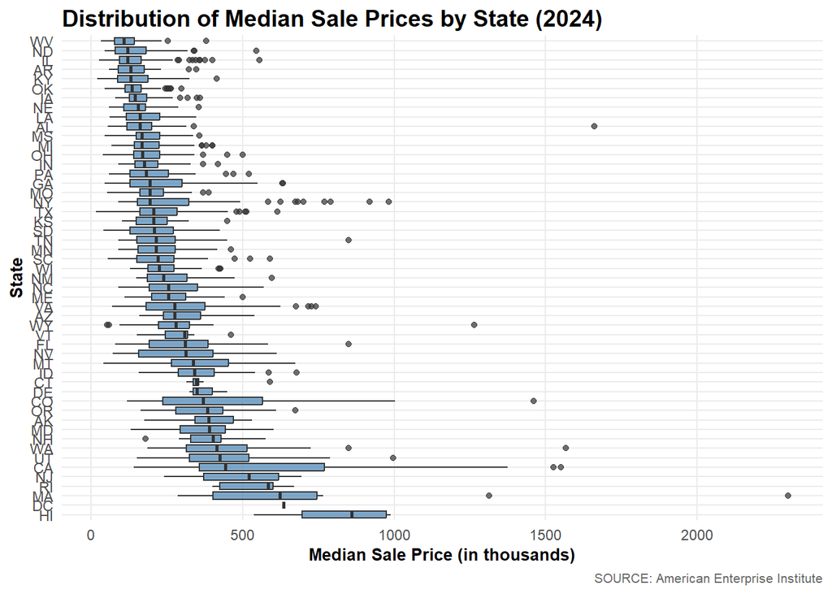

```r
#boxplotting med sale price by state w/ ..._all df
#all
med_sale_price_by_state_boxplot = ggplot(housing_2024_all,
                                         aes(x = reorder(State, -Median_Sale_Price_in_k, median),
                                             y = Median_Sale_Price_in_k)) +
  geom_boxplot(fill = "steelblue", alpha = 0.7) +
  coord_flip() +
  labs(
    title = "Distribution of Median Sale Prices by State (2024)",
    x = "State",
    y = "Median Sale Price (in thousands)",
    caption = "SOURCE: American Enterprise Institute") +
  theme(axis.text.y = element_text(size = 5)) +
  theme_minimal()+
  theme(plot.title = element_text(face = "bold",
                                  size = 14,
                                  margin = margin(b = 3)),
        plot.subtitle = element_text(size = 10,
                                     color = "gray25",
                                     margin = margin(b = 8)),
        axis.title = element_text(size = 10,
                                  face = "bold"),
        axis.text = element_text(size = 9),
        plot.caption = element_text(size = 8,
                                    color = "gray40",
                                    hjust = 1),
        panel.grid.minor = element_blank(),
        panel.background = element_blank(),
        plot.background = element_blank())
#next round, would want to nix outliers

med_sale_price_by_state_boxplot
```

```r
# ggsave("med_sale_price_by_state_boxplot.png", plot = med_sale_price_by_state_boxplot,
#        width = 10, height = 10, dpi = 300)
```

This graph allowed us to see the trend of median sale price distribution among states. However, the graph is too busy to be particularly useful. You can see general trends, but a smaller sample improves legibility.

### Top and Bottom Months’ Supply Analysis

We subsetted the dataset in order to have a smaller sample to visualize and analyze our data. By isolating the states with the highest and lowest Months’ Supply, we were able to better visualize the difference in how Months’ Supply correlates with other variables of interest.

The states that fell into these groups are:

```r
#boxplotting with new df: ..._all
#Find top/bottom 5 by median Months' Supply, not row count
states_by_median_months_supply <- housing_2024_all %>%
  group_by(State) %>%
  summarize(Median_Months_Supply = median(Months_Supply))

top_states_all = states_by_median_months_supply %>% slice_max(order_by = Median_Months_Supply, n = 5)

bottom_states_all <- states_by_median_months_supply %>% slice_min(order_by = Median_Months_Supply, n = 5)

#merge top and bottom states
housing_compare_all <- housing_2024_all %>%
  filter(State %in% c(top_states_all$State, bottom_states_all$State)) %>%
  mutate(StateGroup = case_when(
    State %in% top_states_all$State ~ "High Months' Supply",
    State %in% bottom_states_all$State ~ "Low Months' Supply")) %>%
  mutate(StateGroup = factor(StateGroup, levels = c("Low Months' Supply", "High Months' Supply")))
```

#### Top Months’ Supply States

```r
top_states_all %>%
  add_column(State_Name = c("Hawaii","District of Columbia", "Florida", "Colorado", "Oregon")) %>%
  relocate(State_Name, .after = State) %>%
  xkabledply
```

Model: State ~ State_Name + Median_Months_Supply

| State | State_Name | Median_Months_Supply |
| --- | --- | --- |
| HI | Hawaii | 7.65 |
| DC | District of Columbia | 6.50 |
| FL | Florida | 5.30 |
| CO | Colorado | 4.80 |
| OR | Oregon | 4.65 |

#### Bottom Months’ Supply States

```r
bottom_states_all %>%
  add_column(State_Name = c("Massachusetts","Wisconsin", "Kentucky",
                            "New Hampshire", "Illinois","Indiana","Mississippi",
                            "North Dakota","Ohio")) %>%
  relocate(State_Name, .after = State) %>%
  xkabledply
```

Model: State ~ State_Name + Median_Months_Supply

| State | State_Name | Median_Months_Supply |
| --- | --- | --- |
| MA | Massachusetts | 1.45 |
| WI | Wisconsin | 1.90 |
| KY | Kentucky | 2.10 |
| NH | New Hampshire | 2.25 |
| IL | Illinois | 2.30 |
| IN | Indiana | 2.30 |
| MS | Mississippi | 2.30 |
| ND | North Dakota | 2.30 |
| OH | Ohio | 2.30 |

Immediately, the subsetted data in the same graph format shows a much clearer vision of the positive association between months’ supply and median sale price.

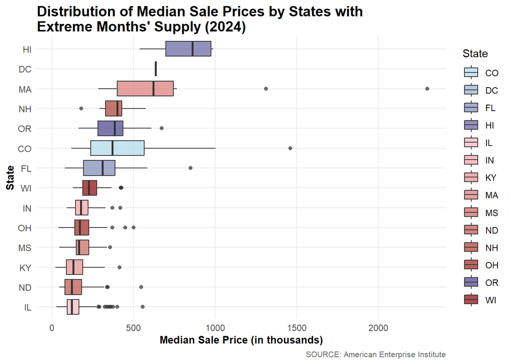

```r
#is prep for the all states factored scatter but
#fix color assigning for side by side compare scatterplots- too many blue showing up
#cleaned plot version with dropped unused (non-10) state levels; re-group by state for clarity
housing_compare_all_plot <- housing_compare_all %>%
  group_by(State, StateGroup) %>%
  summarize(
    Median_Sale_Price_in_k = median(Median_Sale_Price_in_k, na.rm = TRUE),
    Months_Supply = median(Months_Supply, na.rm = TRUE),
    .groups = "drop") %>%
  mutate(State = forcats::fct_drop(State))

#also fixing subset of housing 2024 all so that gray background dots are 1/state
housing_2024_all_plot <- housing_2024_all %>%
  group_by(State) %>%
  summarize(
    Median_Sale_Price_in_k = median(Median_Sale_Price_in_k, na.rm = TRUE),
    Months_Supply = median(Months_Supply, na.rm = TRUE),
    .groups = "drop")

#label points for 10 states
label_points_all <- housing_compare_all_plot

#using cleaned version of plot data to assign colors
top_states_colors_all <- scales::seq_gradient_pal("lightblue", "darkslateblue")(seq(0, 1, length.out = length(unique(housing_compare_all_plot$State[housing_compare_all_plot$StateGroup == "High Months' Supply"]))))
names(top_states_colors_all) <- unique(housing_compare_all_plot$State[housing_compare_all_plot$StateGroup == "High Months' Supply"])

bottom_states_colors_all <- scales::seq_gradient_pal("lightpink", "darkred")(seq(0, 1, length.out = length(unique(housing_compare_all_plot$State[housing_compare_all_plot$StateGroup == "Low Months' Supply"]))))
names(bottom_states_colors_all) <- unique(housing_compare_all_plot$State[housing_compare_all_plot$StateGroup == "Low Months' Supply"])

state_colors_all <- c(top_states_colors_all, bottom_states_colors_all)

#boxplotting med sale price by state w/ ..._compare_all df
#all
ggplot(housing_compare_all, aes(x = reorder(State, Median_Sale_Price_in_k, median),
                         y = Median_Sale_Price_in_k,
                         fill = State)) +
  geom_boxplot(alpha = 0.7) +
  scale_fill_manual(values = state_colors_all) +
  coord_flip() +
  labs(
    title = "Distribution of Median Sale Prices by States with\nExtreme Months' Supply (2024)",
    x = "State",
    y = "Median Sale Price (in thousands)",
    caption = "SOURCE: American Enterprise Institute") +
  theme_minimal()+
  theme(plot.title = element_text(face = "bold",
                                  size = 14,
                                  margin = margin(b = 3)),
        plot.subtitle = element_text(size = 10,
                                     color = "gray25",
                                     margin = margin(b = 8)),
        axis.title = element_text(size = 10,
                                  face = "bold"),
        axis.text = element_text(size = 9),
        plot.caption = element_text(size = 8,
                                    color = "gray40",
                                    hjust = 1),
        panel.grid.minor = element_blank(),
        panel.background = element_blank(),
        plot.background = element_blank())
```

We also looked at the distribution of the subset of states’ months’ supply of housing.

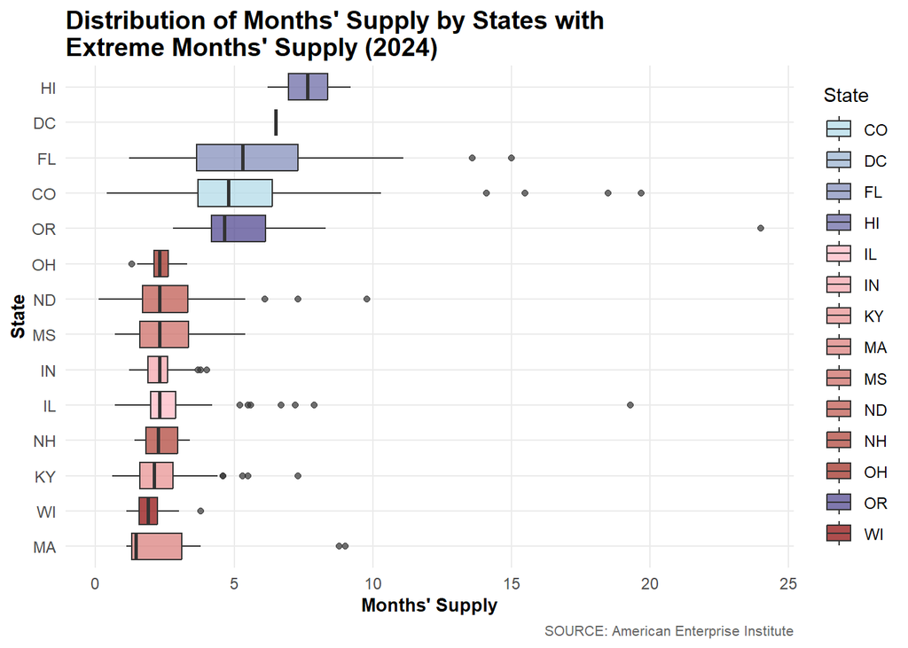

```r
#hist of Months' Supply
supply12hist <- ggplot(housing_compare_all,
       aes(x = reorder(State, Months_Supply, median),
           y = Months_Supply,
           fill = State)) +
  geom_boxplot(alpha = 0.7) +
  scale_fill_manual(values = state_colors_all) +
  coord_flip() +
  labs(title = "Distribution of Months' Supply by States with\nExtreme Months' Supply (2024)",
    x = "State",
    y = "Months' Supply",
    caption = "SOURCE: American Enterprise Institute") +
  theme_minimal() +
  theme(plot.title = element_text(face = "bold", size = 14, margin = margin(b = 3)),
    plot.subtitle = element_text(size = 10, color = "gray25", margin = margin(b = 8)),
    axis.title = element_text(size = 10, face = "bold"),
    axis.text = element_text(size = 9),
    plot.caption = element_text(size = 8, color = "gray40", hjust = 1),
    panel.grid.minor = element_blank(),
    panel.background = element_blank(),
    plot.background = element_blank())

# ggsave("housing_supply_12_hist.png", plot = supply12hist, width = 10, height = 6, dpi = 300)

supply12hist
```

```r
#needs a subtitle with commentary, just remembered all need a caption with the source named, and we can prob add other elements to this, because otherwise it seems to obvi to me

#some other supply dist graph? full 50 I think

#z score
#confidence interval (on what tho, maybe median sale price and Months' Supply)
#then add Zscore and CI onto scatterplot somehow?
```

As you can see, there is over a six month difference in supply of housing between the states with the lowest and highest counts (Massachusetts and Hawaii).